# Colorado

Marcela Suárez

November 19, 2019

This document presents the results obtained for Colorado.

## **Analysis with the whole dataset**

#### **A general overview of the dataset**

```
## Classes 'spec_tbl_df', 'tbl_df', 'tbl' and 'data.frame': 5915 obs. of  7 variables:
##  $ lat      : num  40 40 42.3 40 40 ...
##  $ lon      : num  -105.3 -105.2 -71.7 -105.3 -105.3 ...
##  $ date     : POSIXct, format: "2013-09-27 11:38:37" "2013-09-27 13:32:11" ...
##  $ state    : chr  "Colorado" "Colorado" "Massachusetts" "Colorado" ...
##  $ text     : chr  "Breakfast looks good. Thanks naturespath. #fitsocial  #healthyfood #boulder @ Millennium Harvest House… http://t.co/KyRHM9PQ0B" "#Volunteering in #boulder clearing up flood trash. Glad to help Fernando today clear out his basement.… http://t.co/L6JsOZ88tw" "I need to go to Bou…
##  $ user     : chr  "Alexandra Williams" "Calan Breckon" "Annelyse Reinertson" "Ian Cairns" ...
##  $ u_profile: chr  "Twin & I R fitness experts.Writer/Editor/Speaker/Radio Host.Fun & Fit. ACE Cert. Contrib.Ed. IDEA Fitness Jrnal"| __truncated__ "- #Gay World Traveller on a year long trip around North America -\r Get Inspired | #GetRAOKT | #TTOT | Currently in #Oklahoma" "21. Painting major @…
```

Tweets were collected from 2013-09-01 00:00:48 to 2013-09-30 23:52:05

#### **Cleaning dataset**

- *Removing retweets:*

  All references to usernames, urls and punctuation and numbers were removed from each tweet in order to prepare the dataset for tokenization.

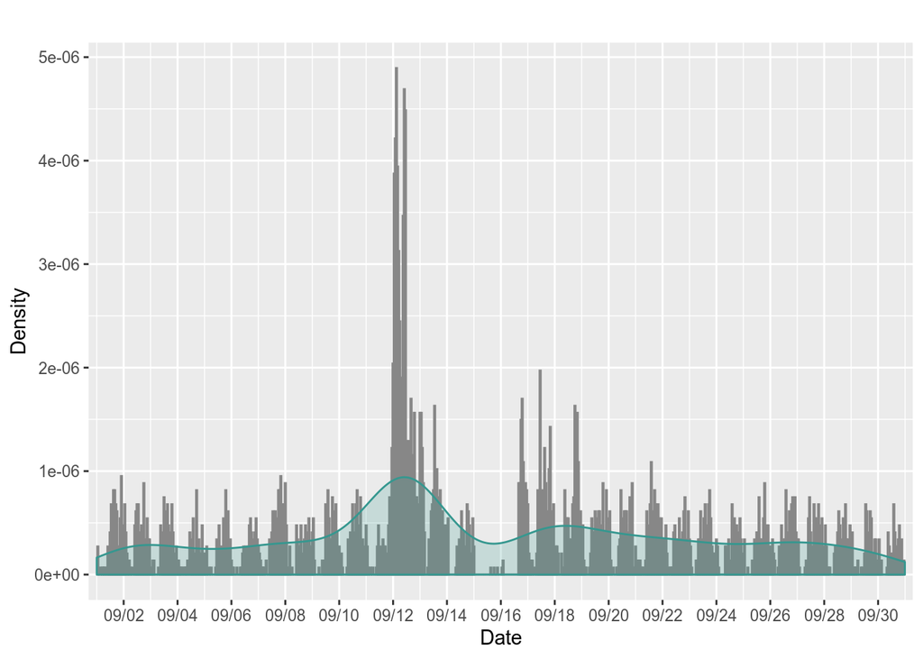

Note: There were only 5 observations on September 15 and only 131 on September 16.

In this stage almost **6%** of the tweets were excluded. 228 tweets from the 4086 total tweets.

#### **Temporal stages**

Four stages were defined:

- *Preflood*: From 2013-09-01 00:00:48 to 2013-09-11 00:00:00.
- *Flood*: From 2013-09-11 00:00:00 to 2013-09-16 00:00:00.
- *Immediate Aftermath*: From 2013-09-16 00:00:00 to 2013-09-23 00:00:00.
- *Postflood*: From 2013-09-23 00:00:00 to 2013-09-30 23:52:05.

Total number of tweets by stage:

| stage | n |
| --- | --- |
| preflood | 983 |
| flood | 1168 |
| immediate_aftermath | 967 |
| postflood | 740 |

#### **Most common words**

A quick view of the most common words in the whole dataset:

```
## # A tibble: 7,410 x 2
##    word             n
##    <chr>        <int>
##  1 boulder       2854
##  2 boulderflood   544
##  3 coflood        427
##  4 colorado       411
##  5 cowx           360
##  6 flood          218
##  7 rain           181
##  8 creek          173
##  9 amp            172
## 10 flooding       163
## # … with 7,400 more rows
```

```
## # A tibble: 7,401 x 2
##    word         n
##    <chr>    <int>
##  1 flood      218
##  2 rain       181
##  3 creek      173
##  4 flooding   163
##  5 denver     137
##  6 day        125
##  7 people     102
##  8 time        94
##  9 park        93
## 10 safe        93
## # … with 7,391 more rows
```

The statistic **tf-idf** was computed in order to identify which words are important in each of the flood stages. It measures how important a word is to a document in a collection (or corpus) of documents, in our case, it measures how important a word is to a tweet in a collection of tweets. In this case the collection of tweets was the set of tweets belonging to each stage.

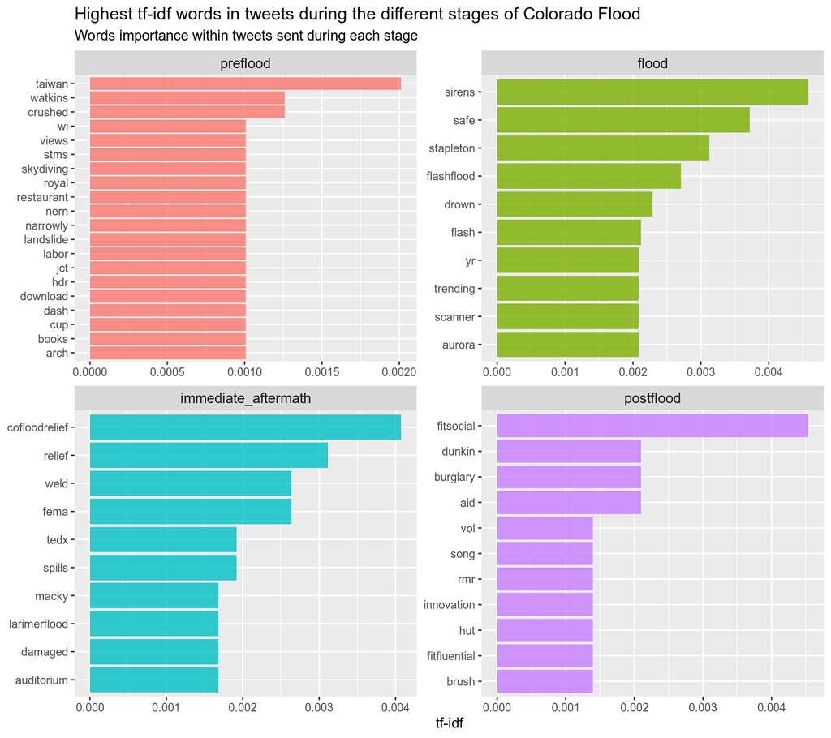

#### **Topic Modeling**

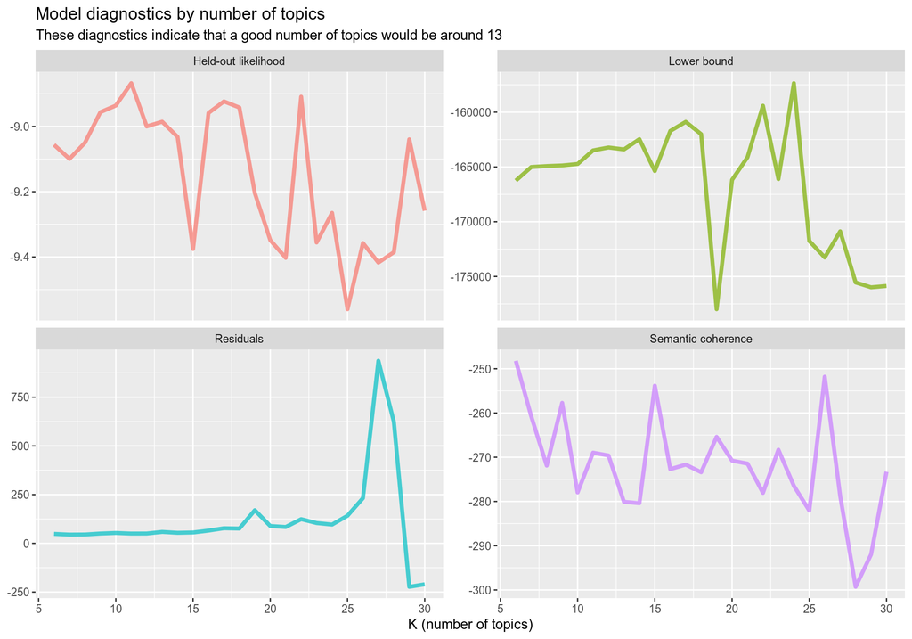

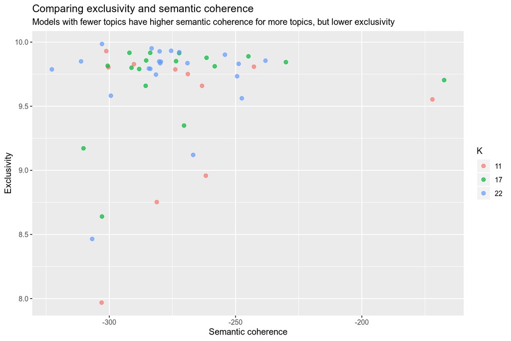

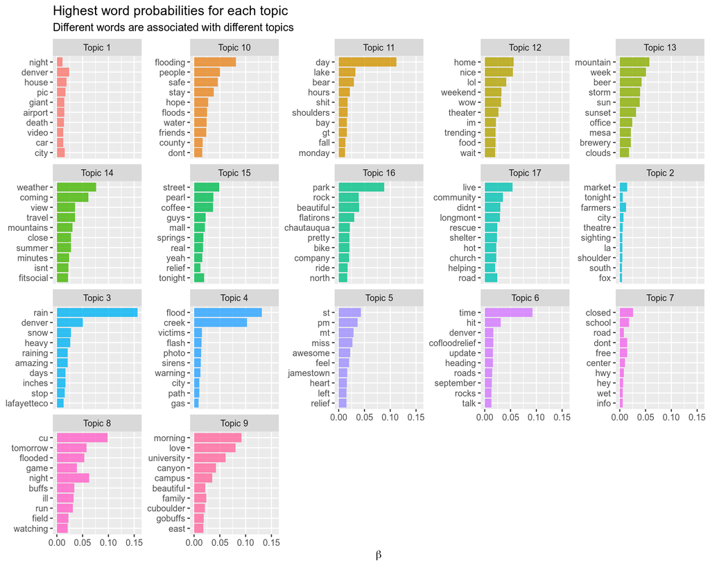

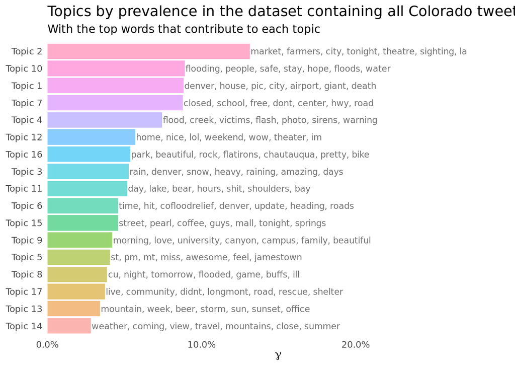

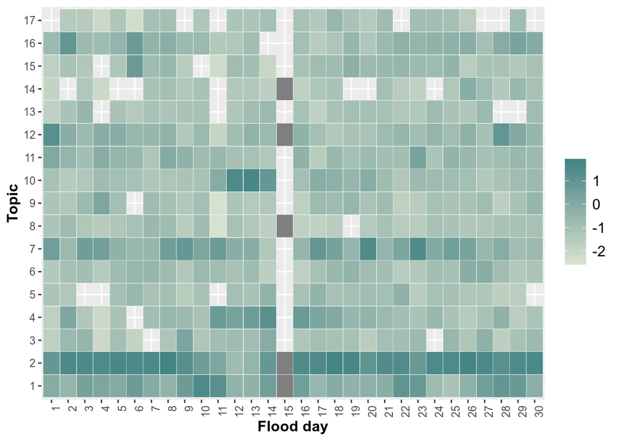